# Model diagnostics: Good classmates

Victoria Bolotova

05 03 2022

# Data preprocessing

```r
library(dplyr)
library(foreign)
library(haven)

initial_df <- read_sav("/Users/victoriabolotova/HSE/HSE 21-22/data_analysis_3rd_year/Practice_OLS/data.sav")

df <- initial_df %>% haven::as_factor()
```

Let’s create two new variables:

```r
# It is the dependent variable
df[,c(65:67)] = sapply(df[,c(65:67)], as.numeric)
df$good_classmates <- rowMeans(df[,c(65:67)], na.rm=TRUE)

# It is an independent variable
df[,c(51:54)] = sapply(df[,c(51:54)], as.numeric)
df$good_freinds = rowMeans(df[,c(51:54)], na.rm = T)
```

Let’s select only variables that will be used in the liner model into another dataset.

```r
df_model <- df %>%
  select(good_classmates, good_freinds, AGE, sex, m96, bulliedothers)
```

Let’s delete all missing values:

```r
df_model <- na.omit(df_model)
nrow(df_model)
```

```
## [1] 24290
```

# Descriptive statistics

Now I am going to explore the most basic information about continuous features.

```r
library(modelsummary)
datasummary_skim(df_model, sparse_header=FALSE)
```

Unique (#)

Missing (%)

Mean

SD

Min

Median

Max

good_classmates

17

0

2.1

0.8

1.0

2.0

5.0

[figure not shown]

good_freinds

37

0

5.5

1.6

1.0

6.0

7.0

AGE

121

0

13.5

1.7

10.5

13.5

16.5

To get an overview of categorical variables:

```r
datasummary_skim(df_model, type="categorical")
```

|  |  | N | % |
| --- | --- | --- | --- |
| sex | Boy | 11893 | 49.0 |
|  | Girl | 12397 | 51.0 |
| m96 | Hardly ever or never | 11958 | 49.2 |
|  | Less than weekly | 5909 | 24.3 |
|  | Weekly | 4634 | 19.1 |
|  | Daily (specified in own variable) | 1789 | 7.4 |
| bulliedothers | Haven’t | 17235 | 71.0 |
|  | Once or twice | 4923 | 20.3 |
|  | 2-3 times per month | 964 | 4.0 |
|  | Once/week | 557 | 2.3 |
|  | Several times/week | 611 | 2.5 |

## Good classmates

This variable was created by taking the means of the following variables:

- `studtogether` - The students in my class(es) enjoy being together
- `studhelpful`- Most of the students in my class(es) are kind and helpful
- `studaccept` - Other students accept me as I am

where 1 means strongly agree with the statement, meanwhile 5 means strongly disagree.

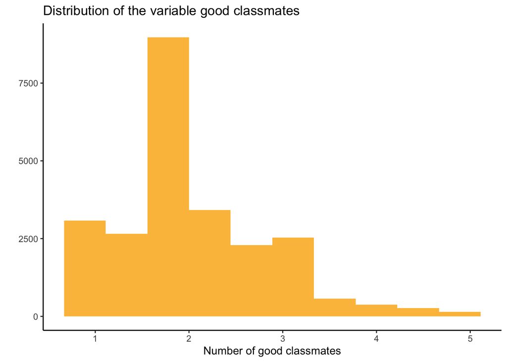

```r
library(ggplot2)
ggplot(df_model, aes(good_classmates)) +
  geom_histogram(fill = "#fcbf49", bins = 10) +
  labs(title = "Distribution of the variable good classmates",
       x = "Number of good classmates",
       y = "") +
  scale_fill_manual("e9c46a") +
  theme_classic()
```

## Good friends

This variable was created by taking the means of the following variables:

- `friendhelp` - My friends really try to help me
- `friendcounton` - Can count on friends
- `friendshare` - I have friends with whom I can share my joys and sorrows
- `friendtalk` - I can talk about my problems with my friends

where 1 means very strongly disagree, meanwhile 7 means very strongly agree.

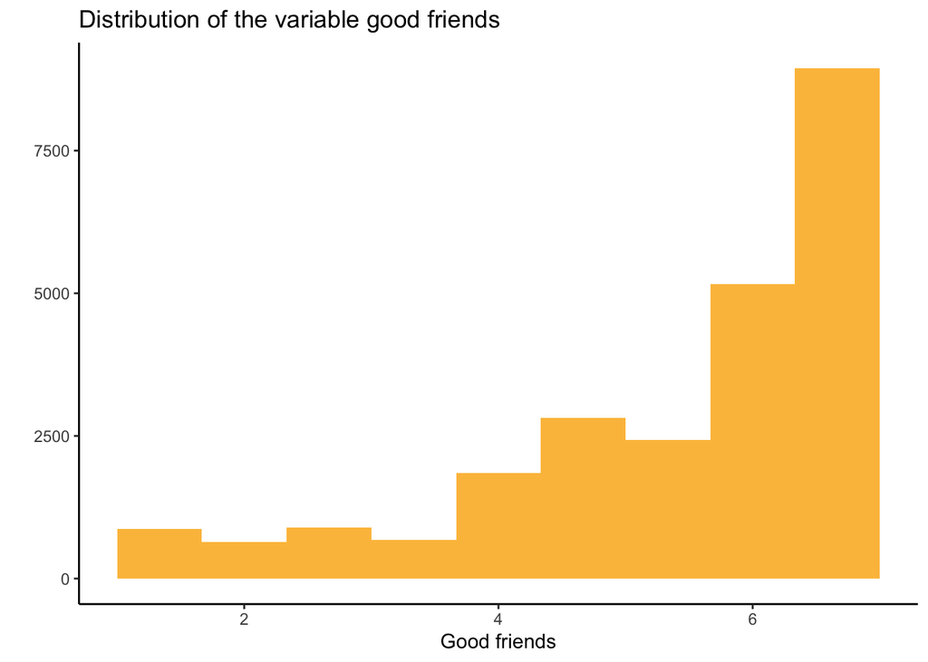

```r
library(ggplot2)
ggplot(df_model, aes(good_freinds)) +
  geom_histogram(fill = "#fcbf49", bins = 10) +
  labs(title = "Distribution of the variable good friends",
       x = "Good friends",
       y = "") +
  scale_fill_manual("e9c46a") +
  theme_classic()
```

## Age

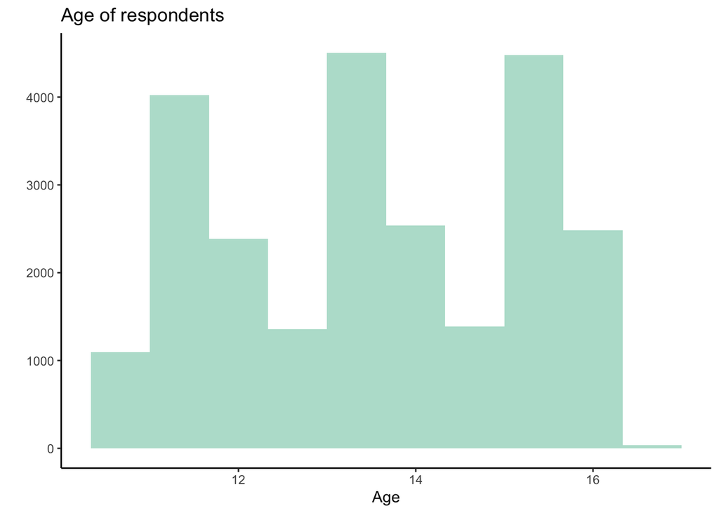

```r
library(ggplot2)
ggplot(df_model, aes(AGE)) +
  geom_histogram(fill = "#b8e0d2", bins = 10) +
  labs(title = "Age of respondents",
       x = "Age",
       y = "") +
  theme_classic()
```

## Sex

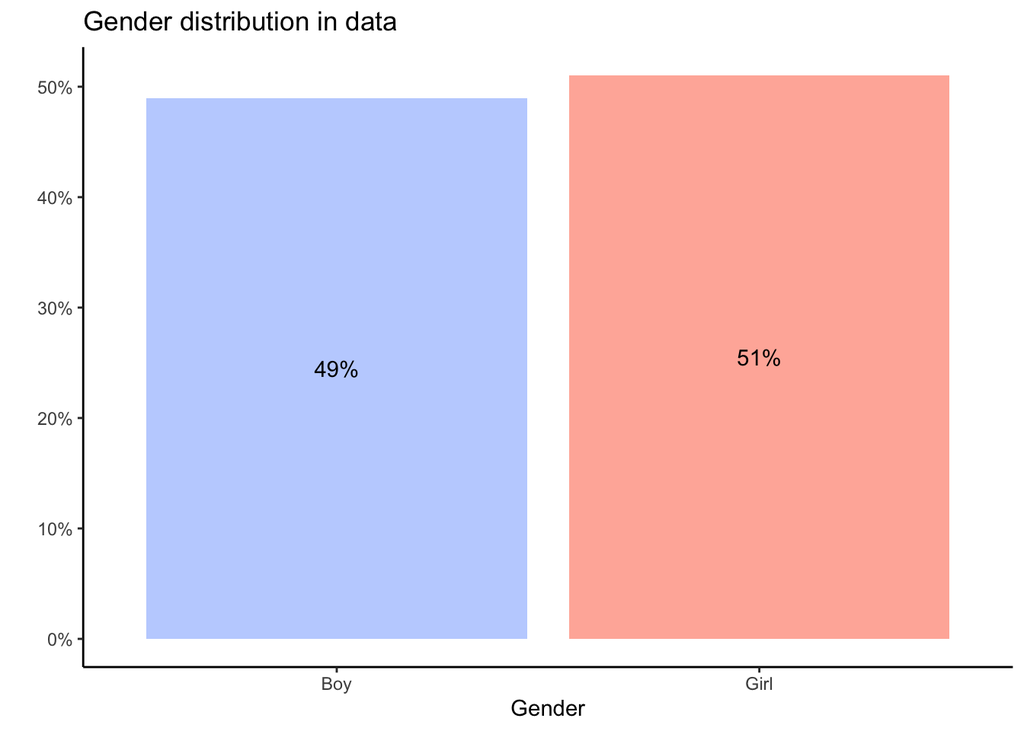

```r
sex_barplot  <- df_model %>%
  group_by(sex) %>%
 dplyr::summarize(count = n()) %>%
 mutate(percentage = count/sum(count))

ggplot(sex_barplot, aes(x = sex, y = percentage, fill = sex)) +
  geom_bar(stat='identity') +
  geom_text(aes(label=scales::percent(percentage)), position = position_stack(vjust = .5)) +
  scale_y_continuous(labels = scales::percent) +
  labs(x="Gender",
       y="",
       title="Gender distribution in data") +
  scale_fill_manual("Gender", values = c('#c1d3fe', '#ffb5a7')) +
  theme_classic() +
  theme(legend.position="none")
```

## Meet friends

- “How often do you meet your friends outside school time after 8 o’clock in the evening?”

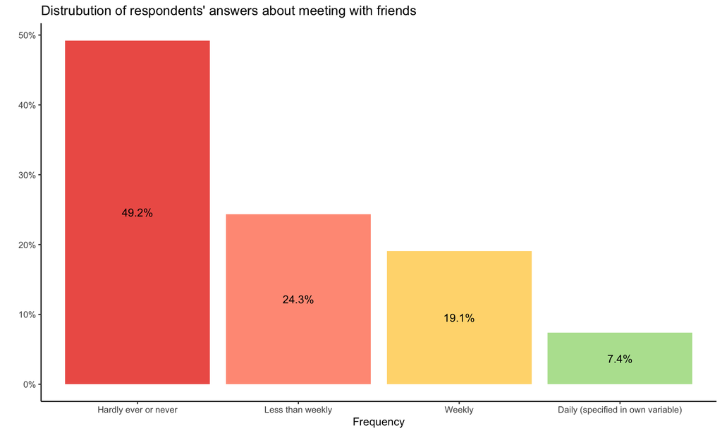

```r
meet_barplot  <- df_model %>%
  group_by(m96) %>%
 dplyr::summarize(count = n()) %>%
 mutate(percentage = count/sum(count))

ggplot(meet_barplot, aes(x = m96, y = percentage, fill = m96)) +
  geom_bar(stat='identity') +
  geom_text(aes(label=scales::percent(percentage)), position = position_stack(vjust = .5)) +
  scale_y_continuous(labels = scales::percent) +
  labs(x="Frequency",
       y="",
       title="Distrubution of respondents' answers about meeting with friends") +
  scale_fill_manual("Meetings", values = c('#ee6055', '#ff9b85', '#ffd97d', '#b6e19e')) +
  theme_classic() +
  theme(legend.position="none")
```

## Bullied others

- How often have you taken part in bullying another student(s) at school in the past couple of months?

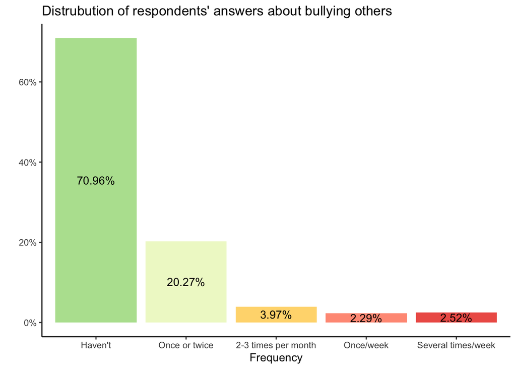

```r
bullied_barplot  <- df_model %>%
  group_by(bulliedothers) %>%
 dplyr::summarize(count = n()) %>%
 mutate(percentage = count/sum(count))

ggplot(bullied_barplot, aes(x = bulliedothers, y = percentage, fill = bulliedothers)) +
  geom_bar(stat='identity') +
  geom_text(aes(label=scales::percent(percentage)), position = position_stack(vjust = .5)) +
  scale_y_continuous(labels = scales::percent) +
  labs(x="Frequency",
       y="",
       title="Distrubution of respondents' answers about bullying others") +
  scale_fill_manual("Meetings", values = c('#b6e19e', '#eff8cd', '#ffd97d', '#ff9b85', '#ee6055')) +
  theme_classic() +
  theme(legend.position="none")
```